# Final Project

## Introduction

In this project, we will explore how music genres, artists, and songs have risen and fallen in popularity over time. We are interested in artist trends in the U.S. because we want to see how artist preferences have changed over the years, what artists have stayed relevant or popular, and what artists have fallen out of popularity. Music is an integral part of society, and culture and music taste can reflect societal attitudes, especially those held by young people. Everyone in our group is an avid music listener, and we are interested in gaining some insight into how music popularity has evolved over time. In our analysis of this subject we worked with 2 seperate datasets. The first dataset we explored was a compiled information on songs and artists that gained enough popularity to be listed on the Billboard Hot 100 list from 2000 to 2020, which is a list of the most listened to songs in the U.S.A. We used this dataset to find summary information concerning which songs were most listened to and which artists made the most revenue, among other things. We utilized the Spotify API to extract supplementary data for the songs in our first dataset. We were able to use this data to search for popular artists that showed up in the analysis of previous dataset, and discover what genre the song or artist writes their music in. We also used this data in later charts to help visualize the analysis we did, which you will see later in our report.

## Summary Information

To get an overview of this topic, we can look at an the data from a higher level to make immediate inferences about our data set.

Our team first looked at which artist showed up the most times on the Top 100 Chart in the last 20 years. We used this as a way to measure popularity. Based on this measurement, we found that the artist who appeared the most times on the chart was Rihanna. This artist appeared a total of 24 times.

We also wanted to know which artist made the most total revenue in the last 20 years to see what revenue says about how popular an artist is. As it turns out, revenue and popularity go hand in hand. The artist with the most revenue was again, Rihanna, who made a total of $179026 over the last 20 years.

Switching gears from looking at artists, we took a look at trends pertaining to songs. We found that the most popular songs on the charts were *Beautiful* and *Sugar*. Popularity was measured the same for songs as it was for artists.

Next, our team wanted to see which song made the most revenue in one year and which song made the least amount of revenue in one year. Just like with artist revenue, song revenue shows whether a song was a real hit, or a real flop. We found that the song that made the most amount of revenue in one year was *Yeah!*. This occured during the year 2004. The song that made the least amount of revenue in one year was *Start Wit Me*, which occured during the year 2020.

## Summary Table

Our group was interested how the top artists have changed over the last 20 years. We decided to define “top artist” as the artist who reached position one on the billboard hot 100 chart in each year. To explore this area of the data, we aggregated data from our chart 2000 dataset to show which artists were in position 1 each year. We grouped this data by year first to collect songs from each individual year, then filtered for songs from each year that reached position 1. The following data shows the arists from each year that reached position one that we deemed as the top artist. We arranged this data in descending order to see the most recent years first.

| Year | Top Artist |
| --- | --- |
| 2020 | Roddy Ricch |
| 2019 | Lil Nas X & Billy Ray Cyrus |
| 2018 | Ed Sheeran |
| 2017 | Ed Sheeran |
| 2016 | Sia |
| 2015 | Mark Ronson & Bruno Mars |
| 2014 | Pharrell Williams |
| 2013 | Robin Thicke, T.I. & Pharrell Williams |
| 2012 | Gotye & Kimbra |
| 2011 | Adele |
| 2010 | Ke$ha |
| 2009 | Lady GaGa |
| 2008 | Leona Lewis |
| 2007 | Rihanna & Jay-Z |
| 2006 | Shakira & Wyclef Jean |
| 2005 | Mariah Carey |
| 2004 | Usher, Lil’ Jon & Ludacris |
| 2003 | 50 Cent |
| 2002 | P Diddy, Usher & Loon |
| 2001 | Lifehouse |
| 2000 | Faith Hill |

## Charts

### Chart 1: Top Five Artists and ‘Hits’ Over Time

This chart shows how many hit songs the top five artists (Rihanna, Pink, Maroon 5, The Black Eyed Peas, and Taylor Swift) from 2000 to 2020 had each year. A ‘hit’ or ‘hit song’ is defined in this dataset and chart to be a song that was included in the top 100 songs of that year, that being, the top 100 songs that generated the most revenue. This chart may also serve as a way to measure an artist’s popularity throughout 2000 - 2020.

Pertinent observations from this chart include:

- The Black Eyed Peas had the highest amount of hits from 2000 - 2020 in 2010 when they had 5 hit songs.
- The Black eyed Peas stopped having any hit songs after 2011.
- Taylor Swift did not have any top hits until 2007.
- Rihanna’s amount of hit songs in a given year appears to peak from 2008 - 2011, where throughout 2008 and 2010 she consistently had 3 hit songs each year and in 2011 she peaked at 4 hit songs.

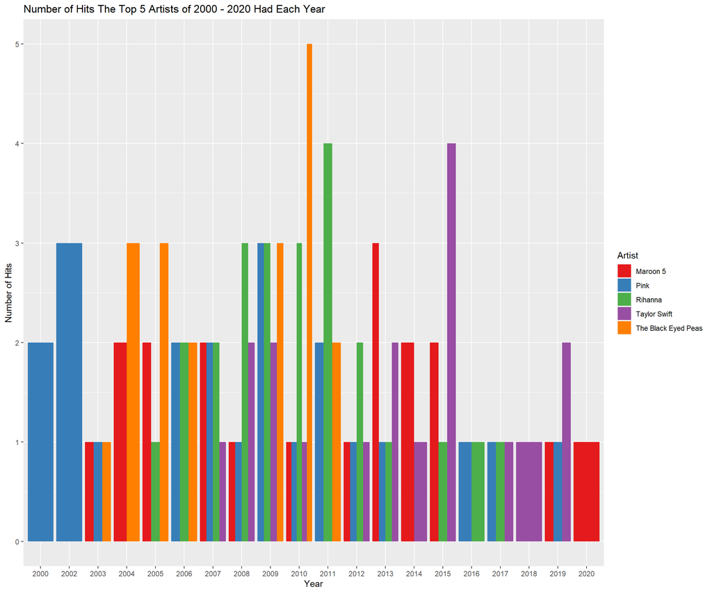

### Chart 2:

Chart 2 is a visualization of the relationship between genre popularity and time. This was the best choice for showing how an individual genre’s popularity changed over time. To measure popularity, we took the top 10 artists from each year and found what genre they write in. Then, we looked at how many times each genre appeared during each year. There were handful of genres that only appeared once or twice over the 21 year period, so we ommited those results.

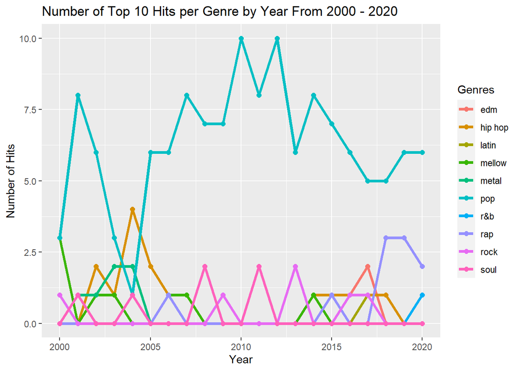

### Chart 3:

Chart 3 is a visual discription of the total indicative revenue of the top songs of 2012 to 2020. Indicative revenue is the complete revenure generated by a song or album over a certain periond. It takes inflation and currency conversion into account. In the chart there are a total of nine songs that are being tracked. These songs are Somebody That I Used To Know, Blurred Lines, Happy, Uptown Funk, Cheap Thrills, Shape of You, Perfect, Old Town Road, and The Box.

Pertinent observations from this chart include:

- In 2017 Shape of you made the most compared to all the other top songs of their year
- With Old Town Road coming in second in the year of 2019
- Unlike the Shape of You, The Box made the least compare to the rest of the songs of their year.

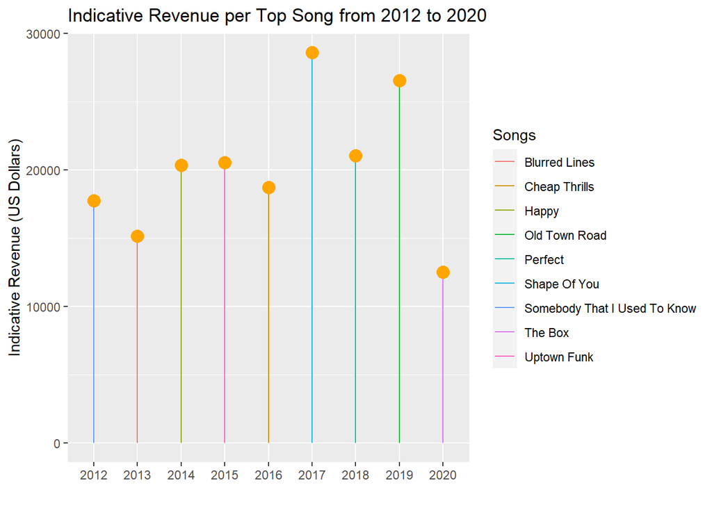